# Does the frozen reader know a person’s first name?

We never ask the model to pick from a list — a forced choice is decided by which name is commoner, not by knowledge (that is why Reagan→Ronald and Sartre→Jean came out falsely high before). We ask how much naming the person lifts the true first name, and then strip out the part of that lift that is language, not knowledge.

**Step one**, the raw lift: boost = log P(first | “the {role} {surname}’s first name was”) − log P(first | “his/her name was”). **Step two**: the frame “the German statesman ___’s first name was” lifts *every* German name, so we subtract the average lift of the plausible wrong names in the same frame (same language, same gender). What is left — the *standout* — is how far the true name is pulled up beyond a typical same-language name. Only a name the model specifically ties to that person survives it.

### How the knowledge line is drawn (no circularity)

What the recentring exposes: most of the raw boost was language priming, not knowledge — in a German frame every German name is lifted several nats, and the honest, person-specific signal is only what the true name adds on top. It survives clearly for distinctively-named figures (Bismarck→Otto) and is weak where the true name is itself common (Einstein→“Albert” does not stand out among German names, though the model has surely met Einstein — a real limit of any first-name test, not a failure of the model). It also disposes of the old role-leakage: “the French philosopher ___ → Jean” lifts Jean for many French surnames, so Jean sits inside the null and the bar rises above it. Nothing is hand-flagged.

## Percent-change view (what you asked for)

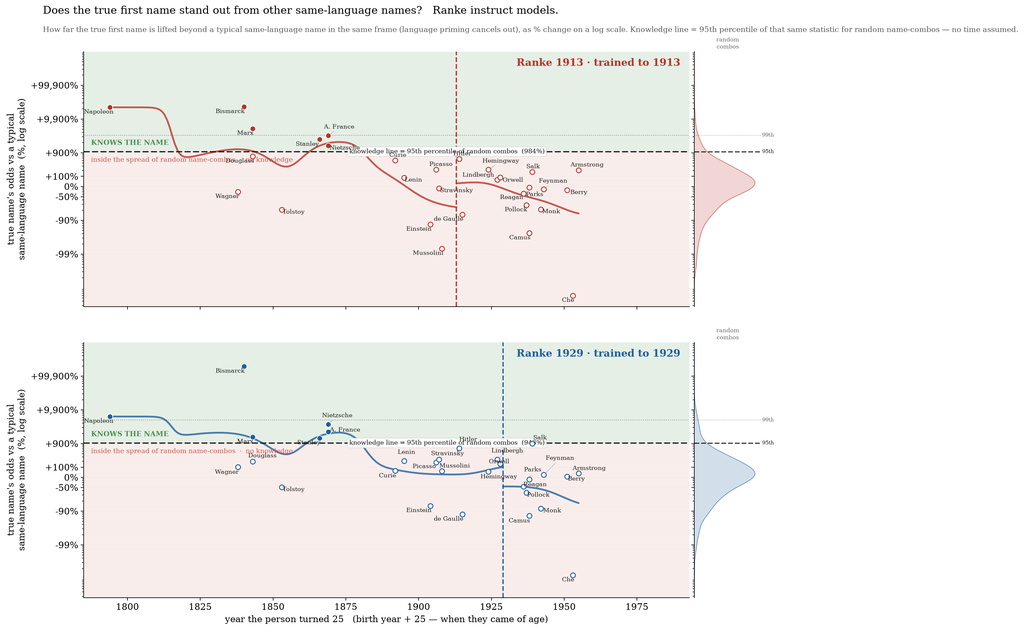

Each dot: how far the true first name stands out beyond a typical same-language name, as % on a log scale. Green = above the knowledge line; rose = inside the random-combo spread. The Bismarck frame makes “Otto” about +193,190% likelier than a typical German name (deep in green); “Ronald” for Reagan is -47% (in the rose spread). This settles the Elvis worry: a few-hundred-percent point still sits below the ~943% line, so it is noise, not knowledge.

## Same data in nats (log-odds)

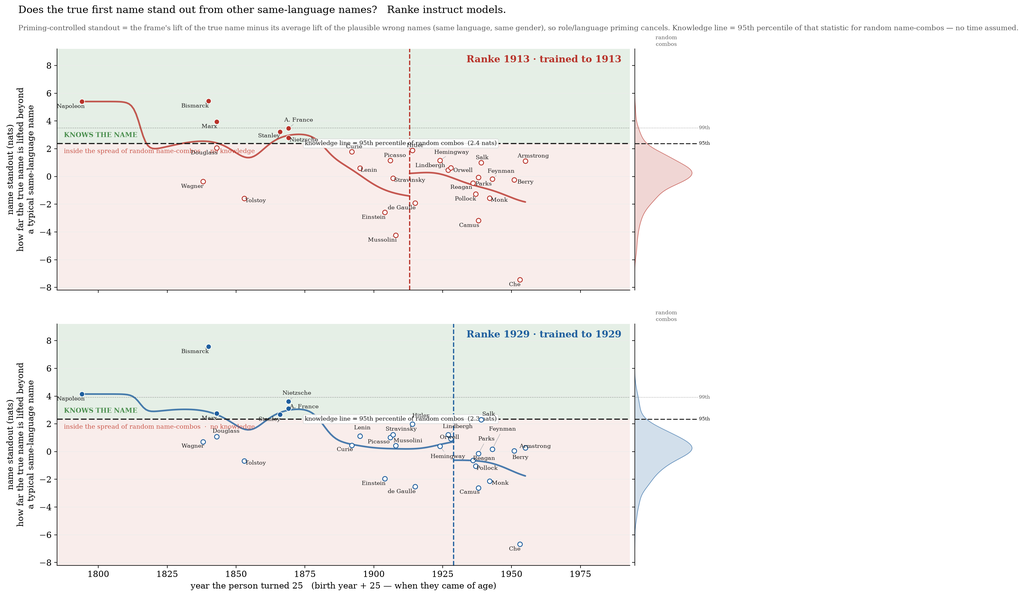

Same picture in nats. Green = above the knowledge line (the name stands out); rose = inside the spread of random name-combos. Solid dots clear the line; hollow do not. The dashed vertical is the model’s cutoff; the trend is in two segments so nothing is smoothed across it. Read-off: the names that clearly stand out are the distinctively-named early figures — Bismarck, Napoleon, Marx, Nietzsche, Anatole France, Stanley — all well inside both windows. Everyone past the cutoff sits in the random-combo spread (Reagan, Parks, Pollock, Guevara, de Gaulle, Camus, Monk, Berry). The time-lock shows as a *rise* across the two models for the in-between figures: Mussolini -4.2→+0.4 nats, Stravinsky -0.1→+1.2 — higher in the 1929 model that trained through their rise, though the priming-controlled bar is strict enough that they approach it rather than vault over.

The French replacements, in standout terms. Anatole France (before both cutoffs; “Anatole” is nobody’s guess) stands out +3.1 nats — clear knowledge by a non-default name. Charles de Gaulle (famous only from 1940) sits at -2.5 and Camus at -2.6 — inside the random-combo spread, correctly not known. “Charles” is common enough to have leaked and did not. The reverse worry — a rare token inflating itself — also fails: Thelonious Monk carries the strangest first name in the set, yet it stands out -2.1 (below zero), and Chuck Berry +0.0. Neither a common name nor a rare one fools the standout; only a name the model ties to the specific person moves it.

## All people: standout (nats), and the two raw boosts behind it

“standout” = raw boost minus the frame’s average wrong-name boost (the number plotted). Pink = came of age after 1929. Knowledge line: 2.4 (1913), 2.3 (1929) nats.

| person | b+25 | standout 1913 | standout 1929 | raw boost 1913 | raw boost 1929 |
| --- | --- | --- | --- | --- | --- |
| Bonaparte → Napoleon | 1794 | +5.4 | +4.1 | +5.7 | +4.7 |
| Wagner → Richard | 1838 | -0.4 | +0.7 | +2.3 | +3.1 |
| Bismarck → Otto | 1840 | +5.4 | +7.6 | +7.1 | +7.8 |
| Marx → Karl | 1843 | +4.0 | +2.7 | +6.3 | +5.6 |
| Douglass → Frederick | 1843 | +2.1 | +1.1 | +1.7 | -0.1 |
| Tolstoy → Leo | 1853 | -1.6 | -0.7 | +3.5 | +4.7 |
| Stanley → Henry | 1866 | +3.2 | +2.7 | +2.4 | +2.0 |
| Nietzsche → Friedrich | 1869 | +2.8 | +3.6 | +6.0 | +6.5 |
| France → Anatole | 1869 | +3.5 | +3.1 | +6.2 | +5.6 |
| Curie → Marie | 1892 | +1.8 | +0.5 | +0.5 | -0.3 |
| Lenin → Vladimir | 1895 | +0.6 | +1.1 | +6.8 | +6.3 |
| Einstein → Albert | 1904 | -2.6 | -1.9 | +1.0 | +1.4 |
| Picasso → Pablo | 1906 | +1.2 | +1.0 | +5.4 | +4.9 |
| Stravinsky → Igor | 1907 | -0.1 | +1.2 | +6.0 | +6.8 |
| Mussolini → Benito | 1908 | -4.2 | +0.4 | +0.6 | +4.2 |
| Hitler → Adolf | 1914 | +1.9 | +2.0 | +5.0 | +5.1 |
| de Gaulle → Charles | 1915 | -1.9 | -2.5 | +1.0 | +0.5 |
| Hemingway → Ernest | 1924 | +1.1 | +0.4 | +1.2 | +0.3 |
| Lindbergh → Charles | 1927 | +0.5 | +1.2 | +0.8 | +0.9 |
| Orwell → George | 1928 | +0.6 | +0.9 | -0.2 | -0.1 |
| Reagan → Ronald | 1936 | -0.5 | -0.6 | -0.6 | -1.0 |
| Pollock → Jackson | 1937 | -1.3 | -1.0 | -0.9 | -1.1 |
| Parks → Rosa | 1938 | -0.1 | -0.1 | -4.3 | -4.1 |
| Camus → Albert | 1938 | -3.2 | -2.6 | -0.6 | +0.2 |
| Salk → Jonas | 1939 | +1.0 | +2.3 | +0.7 | +1.9 |
| Monk → Thelonious | 1942 | -1.6 | -2.1 | -1.1 | -2.0 |
| Feynman → Richard | 1943 | -0.2 | +0.2 | -0.1 | -0.1 |
| Berry → Chuck | 1951 | -0.2 | +0.0 | -0.1 | -0.0 |
| Guevara → Che | 1953 | -7.4 | -6.7 | -2.7 | -2.1 |
| Armstrong → Neil | 1955 | +1.1 | +0.3 | +1.7 | +0.6 |